# Final Report

Author

Dana Kilbourne

## Introduction

The main point of my project is to answer two questions: Is my music taste basic compared to the entire world? Was my Apple Music Replay accurate?

I found a data table on a website showing all of the top songs from 2024 on Spotify world wide. I scraped this data table to use it to compare the songs, artists, and albums I listened to in 2024 to the songs the entire world was listening to.

When Apple Music Replay came out last year, I requested my data to be sent to me from Apple Music. Using this data, I am going to find out if the Apple Music Replay (their version of Spotify Wrapped) was accurate according to the data they have.

## Finding and Cleaning Data

Use a webpage to scrape the top songs from 2024

```python
import requests
import pandas as pd
from bs4 import BeautifulSoup

# get the webpage content
url = "https://kworb.net/spotify/songs_2024.html"
response = requests.get(url)

#beautiful soup
soup = BeautifulSoup(response.content, "html.parser")

# find the table on the page (based on class or tag)
table = soup.find("table")

# extract the headers (column names) from the table
headers = []
for th in table.find_all("th"):
    headers.append(th.get_text(strip=True))

# extract rows of data from the table
rows = []
for tr in table.find_all("tr")[1:]:  # Skip the first row (header)
    cols = tr.find_all("td")
    row = [col.get_text(strip=True) for col in cols]
    rows.append(row)

# convert the list of rows into a DataFrame
top_songs_2024 = pd.DataFrame(rows, columns=headers)

# display the DataFrame
print(top_songs_2024.head())

## clean the data - we want artist and title split
# Assuming the "Artist - Title" column is named 'Song' or similar
top_songs_2024[['artist', 'title']] = top_songs_2024['Artist and Title'].str.split(' - ', expand=True)

print(top_songs_2024.head())

#change the data type to numeric and get rid of the commas using regex for graphing later

print(top_songs_2024['Streams'].dtype)

top_songs_2024['Streams'] = top_songs_2024['Streams'].replace({',': '', '$': '', ' ': ''}, regex=True)


top_songs_2024['Streams'] = pd.to_numeric(top_songs_2024['Streams'], errors = 'coerce')


print(top_songs_2024.head())
```

```
                     Artist and Title        Streams      Daily
0  Billie Eilish - BIRDS OF A FEATHER  2,126,764,510  5,831,445
1                   SAINt JHN - Roses  2,038,344,421    269,414
2        Sabrina Carpenter - Espresso  1,977,140,175  3,278,343
3        Lady Gaga - Die With A Smile  1,938,870,521  8,242,102
4     Benson Boone - Beautiful Things  1,864,112,844  2,996,139
                     Artist and Title        Streams      Daily  \
0  Billie Eilish - BIRDS OF A FEATHER  2,126,764,510  5,831,445
1                   SAINt JHN - Roses  2,038,344,421    269,414
2        Sabrina Carpenter - Espresso  1,977,140,175  3,278,343
3        Lady Gaga - Die With A Smile  1,938,870,521  8,242,102
4     Benson Boone - Beautiful Things  1,864,112,844  2,996,139

              artist               title
0      Billie Eilish  BIRDS OF A FEATHER
```

[output cut: 18 more lines]

## My Apple Music Data

```python
##### Apple Music Play Activity

### actual song history
dana_song_history = pd.read_csv('C:/Users/kilbo/Documents/Spring 2025/Unstructured Data Analytics/Apple_Media_Services/Apple Music Activity/Apple Music - Play History Daily Tracks.csv')
# clean the data
#only want 2024
# Convert the date column to string, then to datetime
dana_song_history['date'] = pd.to_datetime(dana_song_history['Date Played'].astype(str), format='%Y%m%d')

# Filter for the year 2024
dana_songs_2024 = dana_song_history[dana_song_history['date'].dt.year == 2024]

#print(dana_songs_2024.head())



#print(dana_songs_2024['Track Description'].dtype)


dana_songs_2024['Track and Artist'] = dana_songs_2024['Track Description'].apply(str)


# split the track columns so I can get the song and track title
dana_songs_2024[['artist', 'song', 'junk']] = dana_songs_2024['Track and Artist'].str.split(' - ', expand=True)

print(dana_songs_2024[['artist', 'song']].head())
```

```
             artist                             song
20569  Taylor Swift  All Too Well (Taylor's Version)
20570  Taylor Swift                    Never Grow Up
20571  Taylor Swift                  Cornelia Street
20572  Taylor Swift     The Story of Us (US Version)
20573  Taylor Swift                           august
```

[output not shown]

## Top artists from both data frames

```python
top_songs_2024.groupby('artist').size().sort_values(ascending=False).head(10)
dana_songs_2024.groupby('artist').size().sort_values(ascending=False).head(10)

#how much more did I listen to my number one artist compared to my number 2 artist

(2489 - 532)/532
```

```
3.6785714285714284
```

The main point of my project is to find out how basic I am compared to the rest of the world. Do I have a lot of the same top artists as everyone in the world? How do my favorite artists compare to the world’s favorite artists? The 10 artists in the world with the most streamed songs on Spotify in 2024 are Taylor Swift, Peso Pluma, Tito Double P, Ariana Grande, Billie Eilish, Sabrina Carpenter, Arijit Singh, Kendrick Lamar, SEVENTEEN, and Future. My top 10 artists that are also in Spotify’s are: Taylor Swift and Sabrina Carpenter. Taylor Swift is the top artist in the world with 27 songs of the most streamed songs on Spotify in 2024 and she is my top artist, I played songs of Swift’s 2,489 times last year, which is 3.67 times more than my next artist (Gracie Abrams).

```python
top_songs_2024[['Artist and Title', 'Streams']].head(10)
dana_songs_2024.groupby('Track and Artist').size().sort_values(ascending=False).head(10)
```

```
Track and Artist
Gracie Abrams - Risk                                          51
boygenius - Satanist                                          45
boygenius - Cool About It                                     45
boygenius - Not Strong Enough                                 44
Taylor Swift - Who’s Afraid of Little Old Me?                 41
Taylor Swift - The Smallest Man Who Ever Lived                41
Sabrina Carpenter - Espresso                                  40
Zach Bryan - I Remember Everything (feat. Kacey Musgraves)    39
boygenius - Revolution 0                                      39
Taylor Swift - The Black Dog                                  38
dtype: int64
```

Also, according to Apple Music’s Replay (similar to Spotify Wrapped) my top 5 songs are: “Not Strong Enough” by boygenius (97 plays), “Cool About It” by boygenius (89 plays), “Risk” by Gracie Abrams (86 plays), “Satanist” by boygenius (82 plays), and “The Smallest Man Who Ever Lived” by Taylor Swift (78 plays). The top 5 in my Apple Music data are “Risk” by Gracie Abrams is the top song appearing 51 times, followed by “Satanist” by boygenius appearing 45 times, “Cool About It” by boygenius appearing 45 times, “Not Strong Enough” by boygenius appearing 44 times, and “The Smallest Man Who Ever Lived” appearing 41 times. There is clearly a discrepancy between each data point here, and one is wrong.

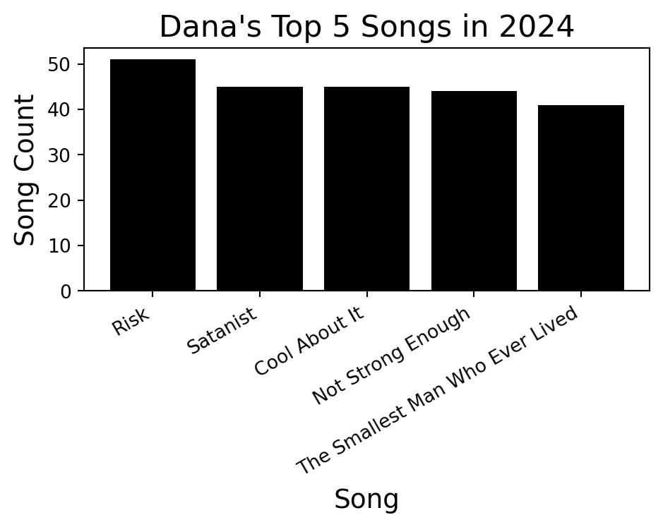

```python
import pandas as pd
import plotly.express as px

import matplotlib.pyplot as plt

# group by, sort them, and select the top 5
top_songs = dana_songs_2024.groupby('song').size().sort_values(ascending=False).head(5)


plt.figure(figsize=(5, 4))
plt.bar(top_songs.index, top_songs.values, color='black')

#add details
plt.title("Dana's Top 5 Songs in 2024", fontsize=16)
plt.xlabel('Song', fontsize=14)
plt.ylabel('Song Count', fontsize=14)
plt.xticks(rotation=30, ha='right')  #rotate x labels to read
plt.tight_layout()  # make everything fit on the graph

# Show the plot
plt.show()
```

Here is a visual showing how many times I listened to my top 5 songs. Compared to my Apply Music Replay, this is very different as explained above.

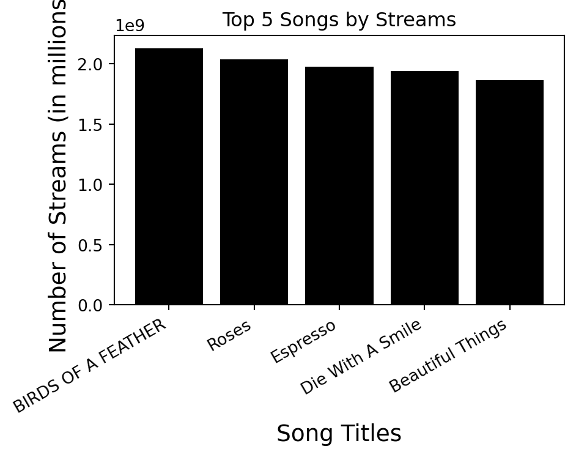

```python
#create the bar chart
plt.figure(figsize=(5, 4))

top_five = top_songs_2024.head(5)

plt.bar(top_five['title'], top_five['Streams'], color='black')

# customize
plt.title('Top 5 Songs by Streams')
plt.xlabel('Song Titles', fontsize = 14)
plt.ylabel('Number of Streams (in millions)', fontsize = 14)
plt.xticks(rotation=30, ha='right')
plt.tight_layout()

#display the chart
plt.show()
```

## My Top Artists

```python
dana_top_artists = dana_songs_2024.groupby('artist')['Play Duration Milliseconds'].sum().reset_index()

dana_top_artists = dana_top_artists.sort_values(by='Play Duration Milliseconds', ascending=False)

# print(dana_top_artists)

dana_top_artists['Minutes Played'] = dana_top_artists['Play Duration Milliseconds'] / 60000  # Convert to minutes

dana_top_artists.sort_values(by = 'Minutes Played', ascending = False).round().head(6)
```

|  | artist | Play Duration Milliseconds | Minutes Played |
| --- | --- | --- | --- |
| 543 | Taylor Swift | 648674900 | 10811.0 |
| 655 | boygenius | 165804756 | 2763.0 |
| 219 | Gracie Abrams | 129947604 | 2166.0 |
| 198 | Fleetwood Mac | 75740486 | 1262.0 |
| 501 | Sabrina Carpenter | 70598312 | 1177.0 |
| 526 | Stevie Nicks | 68086041 | 1135.0 |

This section is about comparing my Apple Music Replay to the data that I have received from Apple Music. As far as my top artists go, Apple Music Replay is sort of accurate. It has Taylor Swift as my top artist with 10,582 minutes listened. My data shows 10,811 minutes listened. This is a small error, like most of them. boygenius is next on both lists and is only 2 minutes apart from each other. Gracie Abrams is third on both lists and again, is only about 16 minutes away. However, Apple Music Replay shows Stevie Nicks as my fourth most popular artist and Fleetwood Mac as my fifth with 1,253 minutes and 1,244 minutes, respectively. My data exploration shows Fleetwood Mac at the fourth spot with Sabrina Carpenter sneaking into the fifth, leaving Stevie Nicks out of my top five artists.

## What is the correlation between my top songs and the total number of streams?

Am I listening to not only the most popular songs, but am I listening to them the same amount as everyone else?

```
                          song             artist     Streams  Count
4           BIRDS OF A FEATHER      Billie Eilish  2126764510      1
18                    Espresso  Sabrina Carpenter  1977140175     40
5             Beautiful Things       Benson Boone  1864112844      6
22            Good Luck, Babe!      Chappell Roan  1302393979      5
41        Please Please Please  Sabrina Carpenter  1270628432     29
..                         ...                ...         ...    ...
59                  The Bolter       Taylor Swift   113903284     28
56               The Albatross       Taylor Swift   112208364     29
16                 Don’t Smile  Sabrina Carpenter   110253852     15
73             thanK you aIMee       Taylor Swift   108149471     29
28  I Look in People's Windows       Taylor Swift   100027773     27

[74 rows x 4 columns]
Correlation between number of streams and my number of plays is: -0.14334130115011282
```

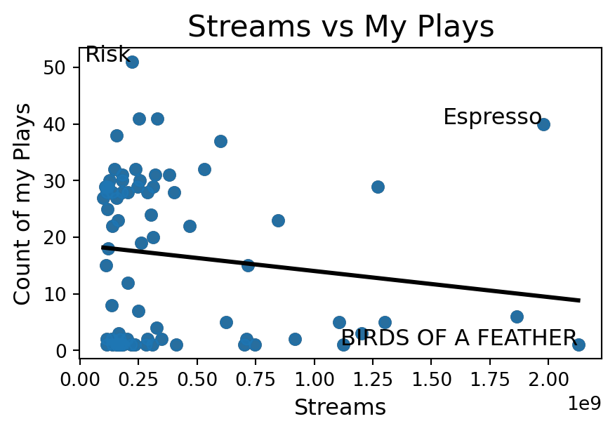

```python
import seaborn as sns
# Rename the 'Title' column in your music data to 'Song' for comparison
top_songs_2024 = top_songs_2024.rename(columns = {'title': 'song'})

dana_top_songs = dana_songs_2024.groupby(['song', 'artist']).size().reset_index(name='Count')

# Merge the two dataframes on 'Song' and 'Artist' to find matches
matching_songs_df = pd.merge(dana_top_songs, top_songs_2024, on=['song', 'artist'], how='inner')

# Rank the common songs by streams (or by plays in your collection if preferred)
matching_songs_df = matching_songs_df.sort_values(by='Streams', ascending=False)  # Sort by 'Streams'

# Show the most popular songs in both datasets
print(matching_songs_df[['song', 'artist', 'Streams', 'Count']])

#correlation between the total streams and my number of plays for a song
correlation = matching_songs_df['Streams'].corr(matching_songs_df['Count'])
print(f"Correlation between number of streams and my number of plays is: {correlation}")



import matplotlib.pyplot as plt



#scatter plot of Sentiment vs Rating
plt.figure(figsize=(5, 3))
plt.scatter(matching_songs_df['Streams'],matching_songs_df['Count'], color='black', alpha=0.7)
sns.regplot(x='Streams', y='Count', data=matching_songs_df, scatter=True, line_kws={'color': 'black'}, ci=None)


# select song for labeling
x_value = matching_songs_df['Streams'][18]
y_value = matching_songs_df['Count'][18]
song_title = matching_songs_df['song'][18]  # Only the song title

# Label the point with the song title only (no artist)
# Add some offset to avoid overlap with the point
plt.text(x_value + 50000, y_value, song_title, horizontalalignment='right', size=12, color='black')

# select another song for labeling
x_value1 = matching_songs_df['Streams'][4]
y_value1 = matching_songs_df['Count'][4]
song_title1 = matching_songs_df['song'][4]  # Only the song title

# Label the point with the song title only (no artist)
# Add some offset to avoid overlap with the point
plt.text(x_value1 + 50000, y_value1, song_title1, horizontalalignment='right', size=12, color='black')

# select another song for labeling
x_value2 = matching_songs_df['Streams'][44]
y_value2 = matching_songs_df['Count'][44]
song_title2 = matching_songs_df['song'][44]  # Only the song title

# Label the point with the song title only (no artist)
# Add some offset to avoid overlap with the point
plt.text(x_value2 + 50000, y_value2, song_title2, horizontalalignment='right', size=12, color='black')

# add labels
plt.title('Streams vs My Plays', fontsize=16)
plt.xlabel('Streams', fontsize=12)
plt.ylabel('Count of my Plays', fontsize=12)

#show the plot
plt.show()
```

This graph shows the songs that overlap between the songs I have played and the most streamed songs in the world. I included labels of a few of the data points to show the most extreme outliers of all the variables: a song that I listened to a lot that did not have a lot of streams, a song that I did not listen to a lot but did have a lot of streams, and a song that I listened to a lot and it did have a lot of streams too. There is a slight negative correlation (-0.14) between the count of my song plays and the number of total streams for the song. There is no clear correlation between the count of my songs played and the total number of streams for a song. Therefore, we must conclude that I do not have a basic music taste.

## Conclusion

According to my correlation between my listens of a song and the number of streams, my music taste is not basic. Out of the ten top artists in the world and my top ten artists, there are only two that overlap. 20% does not make someone basic. Out of the top five songs in the world and my top five songs, there are no songs that over lap. That also concludes my music taste not being basic.

And, as always:

```python
#
link_fuck = "https://foass.1001010.com/this/Dana"


# URL of the webpage

# Send an HTTP GET request to the website
fuck_response = requests.get(link_fuck)

# Check if the request was successful
if response.status_code == 200:
    # Parse the HTML content with BeautifulSoup
    fuck_soup = BeautifulSoup(fuck_response.text, 'html.parser')

    # Now, extract the sentence or content you're looking for
    # You can inspect the webpage structure using developer tools (F12 in most browsers)
    # If the sentence is in a specific tag (e.g., <p>, <h1>, etc.), you can extract it.

    # Example: Get all text inside <p> tags (for paragraphs)
    paragraphs = fuck_soup.find_all('h1')

    for para in paragraphs:
        print(para.get_text())

    # If you're looking for a specific sentence or text, you might need to refine this logic.
    # For example, if the sentence you want is in a specific class:
    # sentence = soup.find('div', class_='specific-class').get_text()

else:
    print(f"Failed to retrieve the page. Status code: {response.status_code}")
```

```
Fuck this
```